# Лабораторная работа No1

Операционные системы

Нджову Н. НКАбд-04-23

Российский университет дружбы народов, Москва, Россия

27 февраля 2024

## Цель работы

Целью данной работы является приобретение практических навыков установки операционной системы на виртуальную машину, настройки минимально необходимых для дальнейшей работы сервисов.

## Задание

1. Создание виртуальной машины
2. Установка операционной системы
3. Работа после установки
4. Установка программного обеспечения для создания документации

## 1. Создание виртуальной машины

Нажав ‘создать’, я создаю новую витуалную машину(рис.1)

[figure not shown]

Создание вм

## 1. Создание виртуальной машины

Я указываю обьем основной памяти витуальной машины размером 4096МБ(рис.2)

[figure not shown]

обьем основной памяти

## 1. Создание виртуальной машины

Я выбираю создание нового витуального жесткого диска

Я установила конфигурацию жесткого диска: загрузочный VDI

Я устанавливаю размер диска равным 120 ГБ(рис.3)

[figure not shown]

размер жесткого диска

## 1. Создание виртуальной машины

Я выбираю динамический виртуальный жесткий диск Я выбираю конфигурацию своей витуальной машины в VirtualBox. Я захожу в раздел ‘Носители’,добавляю новый оптический дискодов и выбираю загруженныйй образ операционной системы Fedora(рис.4)

[figure not shown]

оптический системы

## 2. Установка операционной системы

Я запускаю созданую витуальную машину для установки

Я вижу интерфейс начальной конфигурации. Я нажимаю Enter, затем нажимаю Enter

Я нажмаю Win+Enter для запуска терминала. В терминала запускаю liveinst(рис.5)

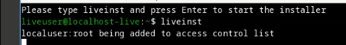

терминал

## 2. Установка операционной системы

Я выбираю язык для использования в процессе установки- английский, потому что мне так удобнее(рис.6)

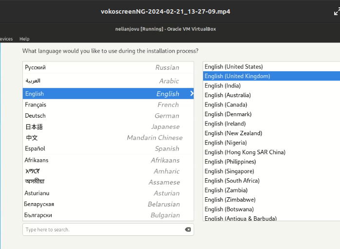

языка

## 2. Установка операционной системы

Я проверяю место установки и сохраняю значение по умольчанию

Я установлю аккаунт администратора и создаю пароль для супер-пользователя

Я создаю пользователя, добавляю адмнистративные привилегии для этой учетной записи, чтобы я мог свободно выполнять команды как супер-пользователя

Далее устанавливается операционная система. После установки я нажимаю “завершить установку”

## 2. Установка операционной системы

Диск не выключился автоматически, поэтому я захожу в настройки, чтобы отключить его(рис.7)

[figure not shown]

диск

## 3. Работа после установки

Я запускаю виртуальную машину. Я вхожу в ОС под учетной записью, которую я установила во время установки(рис.8)

[figure not shown]

вход в ОС

## 3. Работа после установки

Я запускаю Win+Enter, чтобы запустить терминал и переключиться на роль супер-пользователя(рис.9)

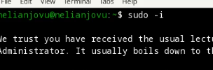

запуски терминала

## 3. Работа после установки

Я устанавливаю программы для удобства работы в консоли;tmux и mc(рис.11)

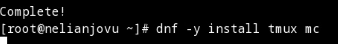

установка tmux и mc

## 3. Работа после установки

Я устанавливаю программы для автоматического обновления(рис.12)

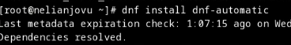

программы для автоматического обновления

## 3. Работа после установки

Я запускаю таймер(рис.13)

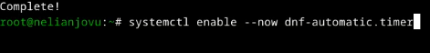

запуски таймера

## 3. Работа после установки

Я перехожу в каталог /etc/selnux, открываю md и ищу нужный мне файл

Перезагружаю витуальную машину

## 3. Работа после установки

Я снова вхожу в ОС, снова запускаю терминал и запускаю терминальный мультиплексор

Я переключаюсь на роль супер-пользователя

Я устанавливаю пакет dkms(рис.15)

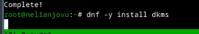

пакет dkms

## 3. Работа после установки

В меню витуальную машины я подключаю образ диска гостевой ОС и монтирую диск с помощью утилиты mount(рис.16)

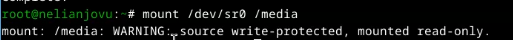

примонтирование диска

## 3. Работа после установки

Я устанавливаю драйверов(рис.17)

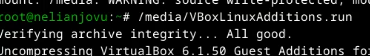

установка драйверов

## 3. Работа после установки

Перезагружаю витуальную машину

Я снова вхожу в ОС, снова запускаю терминал и запускаю терминальный мультиплексор

пойск файла

## 3. Работа после установки

Я редактирую конфигурационный файл(рис.19)

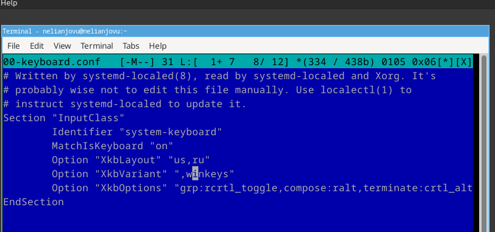

редактирование файла

Перезагружаю витуальную машину

## 4. Установка программного обеспечения для создания документации

Я запускаю терминал, запускаю терминальный мультиплексор tmux, переключаюсь на роль супер-пользователя. Потом я устанавливаю pandoc, испоьзуя команду dnf и флаг - y, который автоматически отвечает на все системные вопросы “да”(рис.20)

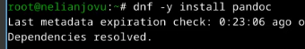

установка pandoc

## 4. Установка программного обеспечения для создания документации

Я устанавливаю дистрибутив texlive(рис.21)

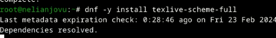

установка texlive

## Выводы

Выполняя эту лабораторную работу, я приобрел практические навыки установки операционной системы на витуальную машину, а также произвел настройка минимальных сервисов, необходимых для дальнейшей работы